# Risk Factor Analysis

## Outcome Variable

**Outcome Variable:** sstunted

## Predictor Variables

**Intervention Variable:** meducyrs

**Adjustment Set:**

- arm
- W_mage
- feducyrs
- hhwealth_quart
- W_mhtcm
- W_mwtkg
- W_mbmi
- W_gagebrth
- W_birthwt
- W_birthlen
- single
- W_nrooms
- impsan
- delta_W_mage
- delta_feducyrs
- delta_hhwealth_quart
- delta_W_mhtcm
- delta_W_mwtkg
- delta_W_mbmi
- delta_W_gagebrth
- delta_W_birthwt
- delta_W_birthlen
- delta_single
- delta_W_nrooms
- delta_impsan

## Stratifying Variables

The analysis was stratified on these variable(s):

- agecat
- studyid
- country

## Data Summary

| agecat | studyid | country | meducyrs | sstunted | n_cell | n |
| --- | --- | --- | --- | --- | --- | --- |
| Birth | ki0047075b-MAL-ED | BANGLADESH | High | 0 | 65 | 187 |
| Birth | ki0047075b-MAL-ED | BANGLADESH | High | 1 | 2 | 187 |
| Birth | ki0047075b-MAL-ED | BANGLADESH | Low | 0 | 62 | 187 |
| Birth | ki0047075b-MAL-ED | BANGLADESH | Low | 1 | 3 | 187 |
| Birth | ki0047075b-MAL-ED | BANGLADESH | Medium | 0 | 53 | 187 |
| Birth | ki0047075b-MAL-ED | BANGLADESH | Medium | 1 | 2 | 187 |
| Birth | ki0047075b-MAL-ED | BRAZIL | High | 0 | 18 | 65 |
| Birth | ki0047075b-MAL-ED | BRAZIL | High | 1 | 0 | 65 |
| Birth | ki0047075b-MAL-ED | BRAZIL | Low | 0 | 17 | 65 |
| Birth | ki0047075b-MAL-ED | BRAZIL | Low | 1 | 0 | 65 |
| Birth | ki0047075b-MAL-ED | BRAZIL | Medium | 0 | 27 | 65 |
| Birth | ki0047075b-MAL-ED | BRAZIL | Medium | 1 | 3 | 65 |
| Birth | ki0047075b-MAL-ED | INDIA | High | 0 | 8 | 40 |
| Birth | ki0047075b-MAL-ED | INDIA | High | 1 | 0 | 40 |
| Birth | ki0047075b-MAL-ED | INDIA | Low | 0 | 18 | 40 |
| Birth | ki0047075b-MAL-ED | INDIA | Low | 1 | 0 | 40 |
| Birth | ki0047075b-MAL-ED | INDIA | Medium | 0 | 12 | 40 |
| Birth | ki0047075b-MAL-ED | INDIA | Medium | 1 | 2 | 40 |
| Birth | ki0047075b-MAL-ED | NEPAL | High | 0 | 5 | 25 |
| Birth | ki0047075b-MAL-ED | NEPAL | High | 1 | 0 | 25 |
| Birth | ki0047075b-MAL-ED | NEPAL | Low | 0 | 12 | 25 |
| Birth | ki0047075b-MAL-ED | NEPAL | Low | 1 | 0 | 25 |
| Birth | ki0047075b-MAL-ED | NEPAL | Medium | 0 | 7 | 25 |
| Birth | ki0047075b-MAL-ED | NEPAL | Medium | 1 | 1 | 25 |
| Birth | ki0047075b-MAL-ED | PERU | High | 0 | 66 | 233 |
| Birth | ki0047075b-MAL-ED | PERU | High | 1 | 2 | 233 |
| Birth | ki0047075b-MAL-ED | PERU | Low | 0 | 83 | 233 |
| Birth | ki0047075b-MAL-ED | PERU | Low | 1 | 1 | 233 |
| Birth | ki0047075b-MAL-ED | PERU | Medium | 0 | 80 | 233 |
| Birth | ki0047075b-MAL-ED | PERU | Medium | 1 | 1 | 233 |

[output cut: 396 more lines]

The following strata were considered:

- agecat: 24 months, studyid: ki0047075b-MAL-ED, country: BANGLADESH
- agecat: 24 months, studyid: ki0047075b-MAL-ED, country: BRAZIL
- agecat: 24 months, studyid: ki0047075b-MAL-ED, country: INDIA
- agecat: 24 months, studyid: ki0047075b-MAL-ED, country: NEPAL
- agecat: 24 months, studyid: ki0047075b-MAL-ED, country: PERU
- agecat: 24 months, studyid: ki0047075b-MAL-ED, country: SOUTH AFRICA
- agecat: 24 months, studyid: ki0047075b-MAL-ED, country: TANZANIA, UNITED REPUBLIC OF
- agecat: 24 months, studyid: ki1000108-CMC-V-BCS-2002, country: INDIA
- agecat: 24 months, studyid: ki1000108-IRC, country: INDIA
- agecat: 24 months, studyid: ki1000109-EE, country: PAKISTAN
- agecat: 24 months, studyid: ki1017093-NIH-Birth, country: BANGLADESH
- agecat: 24 months, studyid: ki1017093b-PROVIDE, country: BANGLADESH
- agecat: 24 months, studyid: ki1017093c-NIH-Crypto, country: BANGLADESH
- agecat: 24 months, studyid: ki1066203-TanzaniaChild2, country: TANZANIA, UNITED REPUBLIC OF
- agecat: 24 months, studyid: ki1113344-GMS-Nepal, country: NEPAL
- agecat: 24 months, studyid: ki1119695-PROBIT, country: BELARUS
- agecat: 24 months, studyid: ki1126311-ZVITAMBO, country: ZIMBABWE
- agecat: 24 months, studyid: ki1135781-COHORTS, country: GUATEMALA
- agecat: 24 months, studyid: ki1135781-COHORTS, country: INDIA
- agecat: 24 months, studyid: ki1135781-COHORTS, country: PHILIPPINES
- agecat: 24 months, studyid: ki1148112-LCNI-5, country: MALAWI
- agecat: 24 months, studyid: kiGH5241-JiVitA-3, country: BANGLADESH
- agecat: 24 months, studyid: kiGH5241-JiVitA-4, country: BANGLADESH
- agecat: 6 months, studyid: ki0047075b-MAL-ED, country: BANGLADESH
- agecat: 6 months, studyid: ki0047075b-MAL-ED, country: BRAZIL
- agecat: 6 months, studyid: ki0047075b-MAL-ED, country: INDIA
- agecat: 6 months, studyid: ki0047075b-MAL-ED, country: NEPAL
- agecat: 6 months, studyid: ki0047075b-MAL-ED, country: PERU
- agecat: 6 months, studyid: ki0047075b-MAL-ED, country: SOUTH AFRICA
- agecat: 6 months, studyid: ki0047075b-MAL-ED, country: TANZANIA, UNITED REPUBLIC OF
- agecat: 6 months, studyid: ki1000108-CMC-V-BCS-2002, country: INDIA
- agecat: 6 months, studyid: ki1000108-IRC, country: INDIA
- agecat: 6 months, studyid: ki1000109-EE, country: PAKISTAN
- agecat: 6 months, studyid: ki1000304b-SAS-CompFeed, country: INDIA
- agecat: 6 months, studyid: ki1000304b-SAS-FoodSuppl, country: INDIA
- agecat: 6 months, studyid: ki1017093-NIH-Birth, country: BANGLADESH
- agecat: 6 months, studyid: ki1017093b-PROVIDE, country: BANGLADESH
- agecat: 6 months, studyid: ki1017093c-NIH-Crypto, country: BANGLADESH
- agecat: 6 months, studyid: ki1066203-TanzaniaChild2, country: TANZANIA, UNITED REPUBLIC OF
- agecat: 6 months, studyid: ki1112895-Guatemala BSC, country: GUATEMALA
- agecat: 6 months, studyid: ki1113344-GMS-Nepal, country: NEPAL
- agecat: 6 months, studyid: ki1119695-PROBIT, country: BELARUS
- agecat: 6 months, studyid: ki1126311-ZVITAMBO, country: ZIMBABWE
- agecat: 6 months, studyid: ki1135781-COHORTS, country: GUATEMALA
- agecat: 6 months, studyid: ki1135781-COHORTS, country: INDIA
- agecat: 6 months, studyid: ki1135781-COHORTS, country: PHILIPPINES
- agecat: 6 months, studyid: ki1148112-LCNI-5, country: MALAWI
- agecat: 6 months, studyid: kiGH5241-JiVitA-3, country: BANGLADESH
- agecat: 6 months, studyid: kiGH5241-JiVitA-4, country: BANGLADESH
- agecat: Birth, studyid: ki0047075b-MAL-ED, country: BANGLADESH
- agecat: Birth, studyid: ki0047075b-MAL-ED, country: BRAZIL
- agecat: Birth, studyid: ki0047075b-MAL-ED, country: INDIA
- agecat: Birth, studyid: ki0047075b-MAL-ED, country: NEPAL
- agecat: Birth, studyid: ki0047075b-MAL-ED, country: PERU
- agecat: Birth, studyid: ki0047075b-MAL-ED, country: SOUTH AFRICA
- agecat: Birth, studyid: ki0047075b-MAL-ED, country: TANZANIA, UNITED REPUBLIC OF
- agecat: Birth, studyid: ki1000108-CMC-V-BCS-2002, country: INDIA
- agecat: Birth, studyid: ki1000108-IRC, country: INDIA
- agecat: Birth, studyid: ki1000109-EE, country: PAKISTAN
- agecat: Birth, studyid: ki1000304b-SAS-CompFeed, country: INDIA
- agecat: Birth, studyid: ki1017093-NIH-Birth, country: BANGLADESH
- agecat: Birth, studyid: ki1017093b-PROVIDE, country: BANGLADESH
- agecat: Birth, studyid: ki1017093c-NIH-Crypto, country: BANGLADESH
- agecat: Birth, studyid: ki1113344-GMS-Nepal, country: NEPAL
- agecat: Birth, studyid: ki1119695-PROBIT, country: BELARUS
- agecat: Birth, studyid: ki1126311-ZVITAMBO, country: ZIMBABWE
- agecat: Birth, studyid: ki1135781-COHORTS, country: GUATEMALA
- agecat: Birth, studyid: ki1135781-COHORTS, country: INDIA
- agecat: Birth, studyid: ki1135781-COHORTS, country: PHILIPPINES
- agecat: Birth, studyid: kiGH5241-JiVitA-3, country: BANGLADESH
- agecat: Birth, studyid: kiGH5241-JiVitA-4, country: BANGLADESH

### Dropped Strata

Some strata were dropped due to rare outcomes:

- agecat: Birth, studyid: ki0047075b-MAL-ED, country: BANGLADESH
- agecat: Birth, studyid: ki0047075b-MAL-ED, country: BRAZIL
- agecat: Birth, studyid: ki0047075b-MAL-ED, country: INDIA
- agecat: Birth, studyid: ki0047075b-MAL-ED, country: NEPAL
- agecat: Birth, studyid: ki0047075b-MAL-ED, country: PERU
- agecat: Birth, studyid: ki0047075b-MAL-ED, country: SOUTH AFRICA
- agecat: Birth, studyid: ki0047075b-MAL-ED, country: TANZANIA, UNITED REPUBLIC OF
- agecat: Birth, studyid: ki1000108-CMC-V-BCS-2002, country: INDIA
- agecat: Birth, studyid: ki1000108-IRC, country: INDIA
- agecat: Birth, studyid: ki1000109-EE, country: PAKISTAN
- agecat: Birth, studyid: ki1017093b-PROVIDE, country: BANGLADESH
- agecat: Birth, studyid: ki1017093c-NIH-Crypto, country: BANGLADESH
- agecat: Birth, studyid: ki1113344-GMS-Nepal, country: NEPAL
- agecat: Birth, studyid: ki1119695-PROBIT, country: BELARUS
- agecat: Birth, studyid: ki1135781-COHORTS, country: GUATEMALA
- agecat: 6 months, studyid: ki0047075b-MAL-ED, country: BANGLADESH
- agecat: 6 months, studyid: ki0047075b-MAL-ED, country: BRAZIL
- agecat: 6 months, studyid: ki0047075b-MAL-ED, country: INDIA
- agecat: 6 months, studyid: ki0047075b-MAL-ED, country: NEPAL
- agecat: 6 months, studyid: ki0047075b-MAL-ED, country: PERU
- agecat: 6 months, studyid: ki0047075b-MAL-ED, country: SOUTH AFRICA
- agecat: 6 months, studyid: ki0047075b-MAL-ED, country: TANZANIA, UNITED REPUBLIC OF
- agecat: 6 months, studyid: ki1000109-EE, country: PAKISTAN
- agecat: 6 months, studyid: ki1000304b-SAS-FoodSuppl, country: INDIA
- agecat: 6 months, studyid: ki1017093-NIH-Birth, country: BANGLADESH
- agecat: 6 months, studyid: ki1017093b-PROVIDE, country: BANGLADESH
- agecat: 6 months, studyid: ki1066203-TanzaniaChild2, country: TANZANIA, UNITED REPUBLIC OF
- agecat: 6 months, studyid: ki1113344-GMS-Nepal, country: NEPAL
- agecat: 24 months, studyid: ki0047075b-MAL-ED, country: BANGLADESH
- agecat: 24 months, studyid: ki0047075b-MAL-ED, country: BRAZIL
- agecat: 24 months, studyid: ki0047075b-MAL-ED, country: INDIA
- agecat: 24 months, studyid: ki0047075b-MAL-ED, country: NEPAL
- agecat: 24 months, studyid: ki0047075b-MAL-ED, country: PERU
- agecat: 24 months, studyid: ki0047075b-MAL-ED, country: SOUTH AFRICA
- agecat: 24 months, studyid: ki0047075b-MAL-ED, country: TANZANIA, UNITED REPUBLIC OF
- agecat: 24 months, studyid: ki1000109-EE, country: PAKISTAN
- agecat: 24 months, studyid: ki1066203-TanzaniaChild2, country: TANZANIA, UNITED REPUBLIC OF
- agecat: 24 months, studyid: ki1113344-GMS-Nepal, country: NEPAL
- agecat: 24 months, studyid: ki1119695-PROBIT, country: BELARUS

## Methods Detail

We’re interested in the causal parameters $E[Y_a]$ for all values of $a \in \mathcal{A}$. These parameters represent the mean outcome if, possibly contrary to fact, we intervened to set all units to have $A=a$. Under the randomization and positivity assumptions, these are identified by the statistical parameters $\psi_a=E_W[E_{Y|A,W}(Y|A=a,W)]$. In addition, we’re interested in the mean of $Y$, $E[Y]$ under no intervention (the observed mean). We will estimate these parameters by using SuperLearner to fit the relevant likelihood factors – $E_{Y|A,W}(Y|A=a,W)$ and $p(A=a|W)$, and then updating our likelihood fit using a joint TMLE.

For unadjusted analyses ($W=\{\}$), initial likelihoods were estimated using Lrnr_glm to estimate the simple $E(Y|A)$ and Lrnr_mean to estimate $p(A)$. For adjusted analyses, a small library containing Lrnr_glmnet, Lrnr_xgboost, and Lrnr_mean was used.

Having estimated these parameters, we will then use the delta method to estimate relative risks and attributable risks relative to a prespecified baseline level of $A$.

# Results Detail

## Results Plots

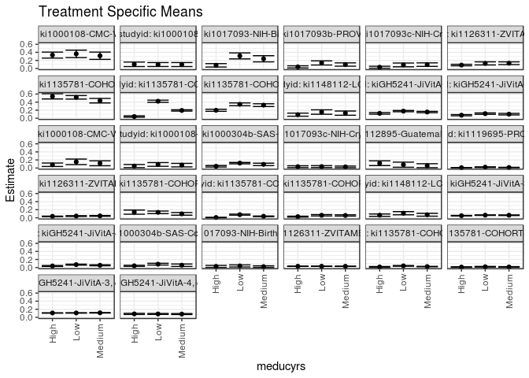

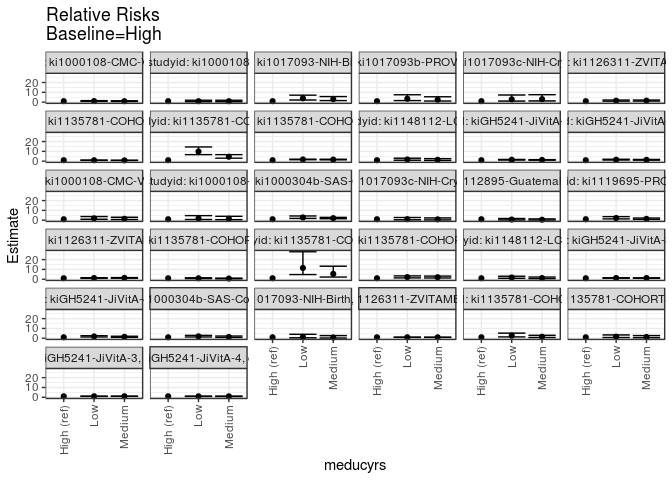

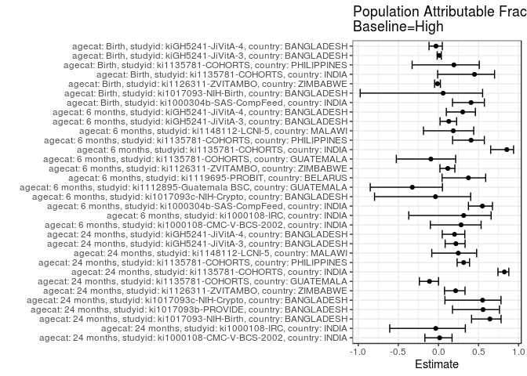

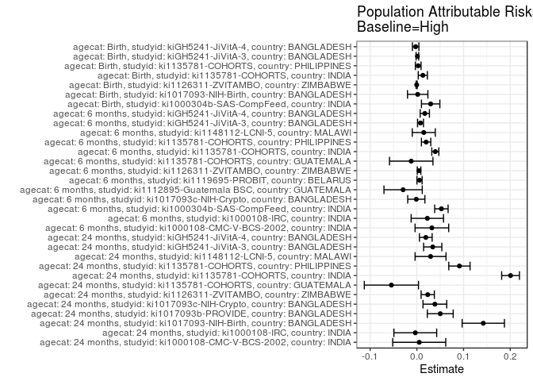

## Results Table

### Parameter: TSM

| agecat | studyid | country | intervention_level | baseline_level | estimate | ci_lower | ci_upper |
| --- | --- | --- | --- | --- | --- | --- | --- |
| Birth | ki1000304b-SAS-CompFeed | INDIA | High | NA | 0.0430905 | 0.0298362 | 0.0563447 |
| Birth | ki1000304b-SAS-CompFeed | INDIA | Low | NA | 0.0838659 | 0.0620979 | 0.1056339 |
| Birth | ki1000304b-SAS-CompFeed | INDIA | Medium | NA | 0.0583115 | 0.0286549 | 0.0879682 |
| Birth | ki1017093-NIH-Birth | BANGLADESH | High | NA | 0.0294118 | 0.0039927 | 0.0548308 |
| Birth | ki1017093-NIH-Birth | BANGLADESH | Low | NA | 0.0401786 | 0.0144406 | 0.0659165 |
| Birth | ki1017093-NIH-Birth | BANGLADESH | Medium | NA | 0.0233645 | 0.0031090 | 0.0436200 |
| Birth | ki1126311-ZVITAMBO | ZIMBABWE | High | NA | 0.0322529 | 0.0291037 | 0.0354021 |
| Birth | ki1126311-ZVITAMBO | ZIMBABWE | Low | NA | 0.0321567 | 0.0281993 | 0.0361142 |
| Birth | ki1126311-ZVITAMBO | ZIMBABWE | Medium | NA | 0.0311282 | 0.0276049 | 0.0346515 |
| Birth | ki1135781-COHORTS | INDIA | High | NA | 0.0156999 | 0.0058219 | 0.0255778 |
| Birth | ki1135781-COHORTS | INDIA | Low | NA | 0.0419176 | 0.0324819 | 0.0513534 |
| Birth | ki1135781-COHORTS | INDIA | Medium | NA | 0.0238234 | 0.0181256 | 0.0295213 |
| Birth | ki1135781-COHORTS | PHILIPPINES | High | NA | 0.0121675 | 0.0051850 | 0.0191500 |
| Birth | ki1135781-COHORTS | PHILIPPINES | Low | NA | 0.0196101 | 0.0104753 | 0.0287450 |
| Birth | ki1135781-COHORTS | PHILIPPINES | Medium | NA | 0.0152495 | 0.0074385 | 0.0230604 |
| Birth | kiGH5241-JiVitA-3 | BANGLADESH | High | NA | 0.1080043 | 0.1027697 | 0.1132389 |
| Birth | kiGH5241-JiVitA-3 | BANGLADESH | Low | NA | 0.1086629 | 0.1037511 | 0.1135746 |
| Birth | kiGH5241-JiVitA-3 | BANGLADESH | Medium | NA | 0.1118048 | 0.1062102 | 0.1173993 |
| Birth | kiGH5241-JiVitA-4 | BANGLADESH | High | NA | 0.0852519 | 0.0704330 | 0.1000707 |
| Birth | kiGH5241-JiVitA-4 | BANGLADESH | Low | NA | 0.0838266 | 0.0712994 | 0.0963538 |
| Birth | kiGH5241-JiVitA-4 | BANGLADESH | Medium | NA | 0.0808805 | 0.0685931 | 0.0931678 |
| 6 months | ki1000108-CMC-V-BCS-2002 | INDIA | High | NA | 0.0816228 | 0.0393295 | 0.1239161 |
| 6 months | ki1000108-CMC-V-BCS-2002 | INDIA | Low | NA | 0.1535243 | 0.0850880 | 0.2219606 |
| 6 months | ki1000108-CMC-V-BCS-2002 | INDIA | Medium | NA | 0.1172829 | 0.0567184 | 0.1778473 |
| 6 months | ki1000108-IRC | INDIA | High | NA | 0.0487805 | 0.0106657 | 0.0868952 |
| 6 months | ki1000108-IRC | INDIA | Low | NA | 0.0890411 | 0.0427870 | 0.1352952 |
| 6 months | ki1000108-IRC | INDIA | Medium | NA | 0.0724638 | 0.0291557 | 0.1157718 |
| 6 months | ki1000304b-SAS-CompFeed | INDIA | High | NA | 0.0432403 | 0.0247091 | 0.0617714 |
| 6 months | ki1000304b-SAS-CompFeed | INDIA | Low | NA | 0.1217324 | 0.1049442 | 0.1385205 |
| 6 months | ki1000304b-SAS-CompFeed | INDIA | Medium | NA | 0.0902075 | 0.0600812 | 0.1203338 |

[output cut: 66 more lines]

### Parameter: E(Y)

| agecat | studyid | country | intervention_level | baseline_level | estimate | ci_lower | ci_upper |
| --- | --- | --- | --- | --- | --- | --- | --- |
| Birth | ki1000304b-SAS-CompFeed | INDIA | NA | NA | 0.0726837 | 0.0523147 | 0.0930527 |
| Birth | ki1017093-NIH-Birth | BANGLADESH | NA | NA | 0.0312500 | 0.0174085 | 0.0450915 |
| Birth | ki1126311-ZVITAMBO | ZIMBABWE | NA | NA | 0.0319018 | 0.0289755 | 0.0348282 |
| Birth | ki1135781-COHORTS | INDIA | NA | NA | 0.0285660 | 0.0240448 | 0.0330871 |
| Birth | ki1135781-COHORTS | PHILIPPINES | NA | NA | 0.0150820 | 0.0107558 | 0.0194081 |
| Birth | kiGH5241-JiVitA-3 | BANGLADESH | NA | NA | 0.1091541 | 0.1045948 | 0.1137135 |
| Birth | kiGH5241-JiVitA-4 | BANGLADESH | NA | NA | 0.0827121 | 0.0710164 | 0.0944078 |
| 6 months | ki1000108-CMC-V-BCS-2002 | INDIA | NA | NA | 0.1138211 | 0.0813725 | 0.1462698 |
| 6 months | ki1000108-IRC | INDIA | NA | NA | 0.0712531 | 0.0462303 | 0.0962759 |
| 6 months | ki1000304b-SAS-CompFeed | INDIA | NA | NA | 0.0958084 | 0.0774939 | 0.1141229 |
| 6 months | ki1017093c-NIH-Crypto | BANGLADESH | NA | NA | 0.0321678 | 0.0192256 | 0.0451101 |
| 6 months | ki1112895-Guatemala BSC | GUATEMALA | NA | NA | 0.0902527 | 0.0564475 | 0.1240580 |
| 6 months | ki1119695-PROBIT | BELARUS | NA | NA | 0.0154178 | 0.0100323 | 0.0208033 |
| 6 months | ki1126311-ZVITAMBO | ZIMBABWE | NA | NA | 0.0405546 | 0.0363986 | 0.0447105 |
| 6 months | ki1135781-COHORTS | GUATEMALA | NA | NA | 0.1281513 | 0.1069071 | 0.1493954 |
| 6 months | ki1135781-COHORTS | INDIA | NA | NA | 0.0463699 | 0.0407674 | 0.0519723 |
| 6 months | ki1135781-COHORTS | PHILIPPINES | NA | NA | 0.0487445 | 0.0406327 | 0.0568562 |
| 6 months | ki1148112-LCNI-5 | MALAWI | NA | NA | 0.0799508 | 0.0612962 | 0.0986054 |
| 6 months | kiGH5241-JiVitA-3 | BANGLADESH | NA | NA | 0.0606764 | 0.0568167 | 0.0645362 |
| 6 months | kiGH5241-JiVitA-4 | BANGLADESH | NA | NA | 0.0562474 | 0.0494699 | 0.0630249 |
| 24 months | ki1000108-CMC-V-BCS-2002 | INDIA | NA | NA | 0.3369272 | 0.2887662 | 0.3850883 |
| 24 months | ki1000108-IRC | INDIA | NA | NA | 0.1002445 | 0.0711031 | 0.1293859 |
| 24 months | ki1017093-NIH-Birth | BANGLADESH | NA | NA | 0.2214452 | 0.1821080 | 0.2607825 |
| 24 months | ki1017093b-PROVIDE | BANGLADESH | NA | NA | 0.0899654 | 0.0666186 | 0.1133122 |
| 24 months | ki1017093c-NIH-Crypto | BANGLADESH | NA | NA | 0.0700389 | 0.0479542 | 0.0921236 |
| 24 months | ki1126311-ZVITAMBO | ZIMBABWE | NA | NA | 0.1086028 | 0.0935351 | 0.1236705 |
| 24 months | ki1135781-COHORTS | GUATEMALA | NA | NA | 0.4881741 | 0.4580257 | 0.5183225 |
| 24 months | ki1135781-COHORTS | INDIA | NA | NA | 0.2436875 | 0.2306994 | 0.2566756 |
| 24 months | ki1135781-COHORTS | PHILIPPINES | NA | NA | 0.2891616 | 0.2711872 | 0.3071359 |
| 24 months | ki1148112-LCNI-5 | MALAWI | NA | NA | 0.1188811 | 0.0923348 | 0.1454274 |
| 24 months | kiGH5241-JiVitA-3 | BANGLADESH | NA | NA | 0.1558984 | 0.1471655 | 0.1646313 |
| 24 months | kiGH5241-JiVitA-4 | BANGLADESH | NA | NA | 0.0953385 | 0.0857703 | 0.1049067 |

### Parameter: RR

| agecat | studyid | country | intervention_level | baseline_level | estimate | ci_lower | ci_upper |
| --- | --- | --- | --- | --- | --- | --- | --- |
| Birth | ki1000304b-SAS-CompFeed | INDIA | High | High | 1.0000000 | 1.0000000 | 1.0000000 |
| Birth | ki1000304b-SAS-CompFeed | INDIA | Low | High | 1.9462759 | 1.2897353 | 2.9370289 |
| Birth | ki1000304b-SAS-CompFeed | INDIA | Medium | High | 1.3532352 | 0.8168488 | 2.2418413 |
| Birth | ki1017093-NIH-Birth | BANGLADESH | High | High | 1.0000000 | 1.0000000 | 1.0000000 |
| Birth | ki1017093-NIH-Birth | BANGLADESH | Low | High | 1.3660714 | 0.4658790 | 4.0056565 |
| Birth | ki1017093-NIH-Birth | BANGLADESH | Medium | High | 0.7943925 | 0.2335614 | 2.7018994 |
| Birth | ki1126311-ZVITAMBO | ZIMBABWE | High | High | 1.0000000 | 1.0000000 | 1.0000000 |
| Birth | ki1126311-ZVITAMBO | ZIMBABWE | Low | High | 0.9970187 | 0.8995673 | 1.1050271 |
| Birth | ki1126311-ZVITAMBO | ZIMBABWE | Medium | High | 0.9651303 | 0.8829801 | 1.0549235 |
| Birth | ki1135781-COHORTS | INDIA | High | High | 1.0000000 | 1.0000000 | 1.0000000 |
| Birth | ki1135781-COHORTS | INDIA | Low | High | 2.6699349 | 1.3682901 | 5.2098253 |
| Birth | ki1135781-COHORTS | INDIA | Medium | High | 1.5174292 | 0.7739553 | 2.9750962 |
| Birth | ki1135781-COHORTS | PHILIPPINES | High | High | 1.0000000 | 1.0000000 | 1.0000000 |
| Birth | ki1135781-COHORTS | PHILIPPINES | Low | High | 1.6116838 | 0.7697165 | 3.3746514 |
| Birth | ki1135781-COHORTS | PHILIPPINES | Medium | High | 1.2532966 | 0.5808544 | 2.7042101 |
| Birth | kiGH5241-JiVitA-3 | BANGLADESH | High | High | 1.0000000 | 1.0000000 | 1.0000000 |
| Birth | kiGH5241-JiVitA-3 | BANGLADESH | Low | High | 1.0060976 | 0.9679515 | 1.0457469 |
| Birth | kiGH5241-JiVitA-3 | BANGLADESH | Medium | High | 1.0351884 | 0.9947047 | 1.0773197 |
| Birth | kiGH5241-JiVitA-4 | BANGLADESH | High | High | 1.0000000 | 1.0000000 | 1.0000000 |
| Birth | kiGH5241-JiVitA-4 | BANGLADESH | Low | High | 0.9832818 | 0.8505251 | 1.1367603 |
| Birth | kiGH5241-JiVitA-4 | BANGLADESH | Medium | High | 0.9487241 | 0.8222421 | 1.0946624 |
| 6 months | ki1000108-CMC-V-BCS-2002 | INDIA | High | High | 1.0000000 | 1.0000000 | 1.0000000 |
| 6 months | ki1000108-CMC-V-BCS-2002 | INDIA | Low | High | 1.8808992 | 0.9474630 | 3.7339526 |
| 6 months | ki1000108-CMC-V-BCS-2002 | INDIA | Medium | High | 1.4368878 | 0.6908427 | 2.9885917 |
| 6 months | ki1000108-IRC | INDIA | High | High | 1.0000000 | 1.0000000 | 1.0000000 |
| 6 months | ki1000108-IRC | INDIA | Low | High | 1.8253425 | 0.7142605 | 4.6647898 |
| 6 months | ki1000108-IRC | INDIA | Medium | High | 1.4855072 | 0.5554590 | 3.9728075 |
| 6 months | ki1000304b-SAS-CompFeed | INDIA | High | High | 1.0000000 | 1.0000000 | 1.0000000 |
| 6 months | ki1000304b-SAS-CompFeed | INDIA | Low | High | 2.8152544 | 1.8352718 | 4.3185196 |
| 6 months | ki1000304b-SAS-CompFeed | INDIA | Medium | High | 2.0861909 | 1.5124593 | 2.8775601 |

[output cut: 66 more lines]

### Parameter: PAR

| agecat | studyid | country | intervention_level | baseline_level | estimate | ci_lower | ci_upper |
| --- | --- | --- | --- | --- | --- | --- | --- |
| Birth | ki1000304b-SAS-CompFeed | INDIA | High | NA | 0.0295933 | 0.0098866 | 0.0492999 |
| Birth | ki1017093-NIH-Birth | BANGLADESH | High | NA | 0.0018382 | -0.0199882 | 0.0236647 |
| Birth | ki1126311-ZVITAMBO | ZIMBABWE | High | NA | -0.0003510 | -0.0015045 | 0.0008024 |
| Birth | ki1135781-COHORTS | INDIA | High | NA | 0.0128661 | 0.0031147 | 0.0226175 |
| Birth | ki1135781-COHORTS | PHILIPPINES | High | NA | 0.0029145 | -0.0032126 | 0.0090415 |
| Birth | kiGH5241-JiVitA-3 | BANGLADESH | High | NA | 0.0011498 | -0.0017026 | 0.0040023 |
| Birth | kiGH5241-JiVitA-4 | BANGLADESH | High | NA | -0.0025398 | -0.0094608 | 0.0043813 |
| 6 months | ki1000108-CMC-V-BCS-2002 | INDIA | High | NA | 0.0321983 | -0.0038162 | 0.0682128 |
| 6 months | ki1000108-IRC | INDIA | High | NA | 0.0224726 | -0.0121801 | 0.0571253 |
| 6 months | ki1000304b-SAS-CompFeed | INDIA | High | NA | 0.0525681 | 0.0381918 | 0.0669445 |
| 6 months | ki1017093c-NIH-Crypto | BANGLADESH | High | NA | -0.0011655 | -0.0195299 | 0.0171989 |
| 6 months | ki1112895-Guatemala BSC | GUATEMALA | High | NA | -0.0294054 | -0.0704132 | 0.0116024 |
| 6 months | ki1119695-PROBIT | BELARUS | High | NA | 0.0057738 | 0.0002508 | 0.0112968 |
| 6 months | ki1126311-ZVITAMBO | ZIMBABWE | High | NA | 0.0047498 | 0.0009415 | 0.0085581 |
| 6 months | ki1135781-COHORTS | GUATEMALA | High | NA | -0.0120605 | -0.0586132 | 0.0344921 |
| 6 months | ki1135781-COHORTS | INDIA | High | NA | 0.0395764 | 0.0320244 | 0.0471283 |
| 6 months | ki1135781-COHORTS | PHILIPPINES | High | NA | 0.0198502 | 0.0098309 | 0.0298694 |
| 6 months | ki1148112-LCNI-5 | MALAWI | High | NA | 0.0148295 | -0.0098567 | 0.0395158 |
| 6 months | kiGH5241-JiVitA-3 | BANGLADESH | High | NA | 0.0078814 | 0.0015738 | 0.0141890 |
| 6 months | kiGH5241-JiVitA-4 | BANGLADESH | High | NA | 0.0170552 | 0.0071393 | 0.0269712 |
| 24 months | ki1000108-CMC-V-BCS-2002 | INDIA | High | NA | 0.0051015 | -0.0517178 | 0.0619208 |
| 24 months | ki1000108-IRC | INDIA | High | NA | -0.0033155 | -0.0491382 | 0.0425072 |
| 24 months | ki1017093-NIH-Birth | BANGLADESH | High | NA | 0.1422904 | 0.0970083 | 0.1875725 |
| 24 months | ki1017093b-PROVIDE | BANGLADESH | High | NA | 0.0501644 | 0.0224541 | 0.0778747 |
| 24 months | ki1017093c-NIH-Crypto | BANGLADESH | High | NA | 0.0386253 | 0.0132246 | 0.0640260 |
| 24 months | ki1126311-ZVITAMBO | ZIMBABWE | High | NA | 0.0233126 | 0.0091482 | 0.0374770 |
| 24 months | ki1135781-COHORTS | GUATEMALA | High | NA | -0.0544893 | -0.1125055 | 0.0035268 |
| 24 months | ki1135781-COHORTS | INDIA | High | NA | 0.2007089 | 0.1816664 | 0.2197514 |
| 24 months | ki1135781-COHORTS | PHILIPPINES | High | NA | 0.0911847 | 0.0683967 | 0.1139728 |
| 24 months | ki1148112-LCNI-5 | MALAWI | High | NA | 0.0294253 | -0.0036906 | 0.0625411 |
| 24 months | kiGH5241-JiVitA-3 | BANGLADESH | High | NA | 0.0340277 | 0.0145430 | 0.0535124 |
| 24 months | kiGH5241-JiVitA-4 | BANGLADESH | High | NA | 0.0191636 | 0.0055652 | 0.0327621 |

### Parameter: PAF

| agecat | studyid | country | intervention_level | baseline_level | estimate | ci_lower | ci_upper |
| --- | --- | --- | --- | --- | --- | --- | --- |
| Birth | ki1000304b-SAS-CompFeed | INDIA | High | NA | 0.4071511 | 0.1757641 | 0.5735811 |
| Birth | ki1017093-NIH-Birth | BANGLADESH | High | NA | 0.0588235 | -0.9758330 | 0.5516761 |
| Birth | ki1126311-ZVITAMBO | ZIMBABWE | High | NA | -0.0110038 | -0.0478265 | 0.0245249 |
| Birth | ki1135781-COHORTS | INDIA | High | NA | 0.4503994 | -0.0095889 | 0.7008081 |
| Birth | ki1135781-COHORTS | PHILIPPINES | High | NA | 0.1932433 | -0.3281226 | 0.5099426 |
| Birth | kiGH5241-JiVitA-3 | BANGLADESH | High | NA | 0.0105341 | -0.0159235 | 0.0363027 |
| Birth | kiGH5241-JiVitA-4 | BANGLADESH | High | NA | -0.0307059 | -0.1169758 | 0.0489009 |
| 6 months | ki1000108-CMC-V-BCS-2002 | INDIA | High | NA | 0.2828851 | -0.1005952 | 0.5327494 |
| 6 months | ki1000108-IRC | INDIA | High | NA | 0.3153911 | -0.3699702 | 0.6578835 |
| 6 months | ki1000304b-SAS-CompFeed | INDIA | High | NA | 0.5486796 | 0.3747695 | 0.6742161 |
| 6 months | ki1017093c-NIH-Crypto | BANGLADESH | High | NA | -0.0362319 | -0.7974273 | 0.4026037 |
| 6 months | ki1112895-Guatemala BSC | GUATEMALA | High | NA | -0.3258120 | -0.8505799 | 0.0501478 |
| 6 months | ki1119695-PROBIT | BELARUS | High | NA | 0.3744884 | 0.0457340 | 0.5899836 |
| 6 months | ki1126311-ZVITAMBO | ZIMBABWE | High | NA | 0.1171219 | 0.0189418 | 0.2054766 |
| 6 months | ki1135781-COHORTS | GUATEMALA | High | NA | -0.0941117 | -0.5250810 | 0.2150709 |
| 6 months | ki1135781-COHORTS | INDIA | High | NA | 0.8534936 | 0.6522116 | 0.9382840 |
| 6 months | ki1135781-COHORTS | PHILIPPINES | High | NA | 0.4072292 | 0.1768233 | 0.5731448 |
| 6 months | ki1148112-LCNI-5 | MALAWI | High | NA | 0.1854833 | -0.1863001 | 0.4407507 |
| 6 months | kiGH5241-JiVitA-3 | BANGLADESH | High | NA | 0.1298921 | 0.0204371 | 0.2271168 |
| 6 months | kiGH5241-JiVitA-4 | BANGLADESH | High | NA | 0.3032184 | 0.0987156 | 0.4613192 |
| 24 months | ki1000108-CMC-V-BCS-2002 | INDIA | High | NA | 0.0151412 | -0.1687865 | 0.1701248 |
| 24 months | ki1000108-IRC | INDIA | High | NA | -0.0330740 | -0.6075433 | 0.3361038 |
| 24 months | ki1017093-NIH-Birth | BANGLADESH | High | NA | 0.6425533 | 0.4137023 | 0.7820764 |
| 24 months | ki1017093b-PROVIDE | BANGLADESH | High | NA | 0.5575966 | 0.1758141 | 0.7625284 |
| 24 months | ki1017093c-NIH-Crypto | BANGLADESH | High | NA | 0.5514834 | 0.0815919 | 0.7809611 |
| 24 months | ki1126311-ZVITAMBO | ZIMBABWE | High | NA | 0.2146594 | 0.0764783 | 0.3321653 |
| 24 months | ki1135781-COHORTS | GUATEMALA | High | NA | -0.1116186 | -0.2375408 | 0.0014908 |
| 24 months | ki1135781-COHORTS | INDIA | High | NA | 0.8236325 | 0.7432636 | 0.8788427 |
| 24 months | ki1135781-COHORTS | PHILIPPINES | High | NA | 0.3153418 | 0.2334045 | 0.3885213 |
| 24 months | ki1148112-LCNI-5 | MALAWI | High | NA | 0.2475184 | -0.0829269 | 0.4771313 |
| 24 months | kiGH5241-JiVitA-3 | BANGLADESH | High | NA | 0.2182683 | 0.0842956 | 0.3326401 |
| 24 months | kiGH5241-JiVitA-4 | BANGLADESH | High | NA | 0.2010062 | 0.0476753 | 0.3296497 |